# Treehugging Study - Results

Scott Claessens

2023-03-08

This document reports the results of multilevel models analysing the distribution of “treehugging” (i.e. valuing nature more than humans) around the world.

We can plot this variable on a global map.

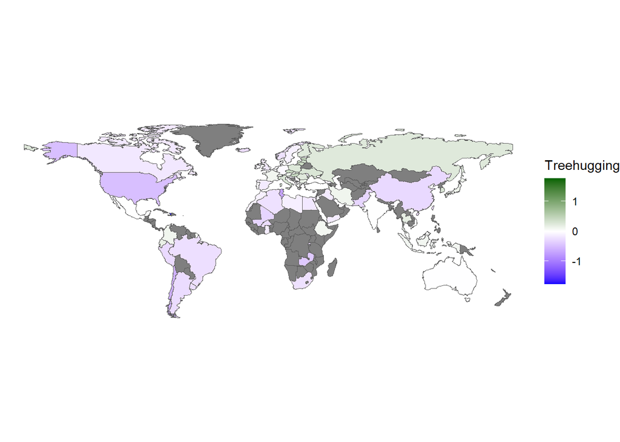

# Intercept-only models

First, we fit a standard random intercept multilevel model with treehugging as the outcome variable and random intercepts for countries and study waves.

```
##  Family: gaussian
##   Links: mu = identity; sigma = identity
## Formula: Treehugging ~ 1 + (1 | year) + (1 | iso)
##    Data: d (Number of observations: 556753)
##   Draws: 4 chains, each with iter = 4000; warmup = 2000; thin = 1;
##          total post-warmup draws = 8000
##
## Group-Level Effects:
## ~iso (Number of levels: 86)
##               Estimate Est.Error l-95% CI u-95% CI Rhat Bulk_ESS Tail_ESS
## sd(Intercept)     0.29      0.02     0.25     0.34 1.00      378      891
##
## ~year (Number of levels: 15)
##               Estimate Est.Error l-95% CI u-95% CI Rhat Bulk_ESS Tail_ESS
## sd(Intercept)     0.07      0.01     0.05     0.10 1.01     1235     2430
##
## Population-Level Effects:
##           Estimate Est.Error l-95% CI u-95% CI Rhat Bulk_ESS Tail_ESS
## Intercept    -0.06      0.04    -0.13     0.01 1.02      175      480
##
## Family Specific Parameters:
##       Estimate Est.Error l-95% CI u-95% CI Rhat Bulk_ESS Tail_ESS
## sigma     1.17      0.00     1.17     1.17 1.00    13420     5562
##
## Draws were sampled using sampling(NUTS). For each parameter, Bulk_ESS
## and Tail_ESS are effective sample size measures, and Rhat is the potential
## scale reduction factor on split chains (at convergence, Rhat = 1).
```

We can get intra-class correlations for countries (`iso`) and study waves (`year`). The ICC for `year` is basically 0, meaning there is no variation in the outcome variable across study waves.

```
## Hypothesis Tests for class :
##                 Hypothesis Estimate Est.Error CI.Lower CI.Upper Evid.Ratio Post.Prob Star
## 1 (sd_year__Interce... = 0        0         0        0     0.01         NA        NA    *
## ---
## 'CI': 90%-CI for one-sided and 95%-CI for two-sided hypotheses.
## '*': For one-sided hypotheses, the posterior probability exceeds 95%;
## for two-sided hypotheses, the value tested against lies outside the 95%-CI.
## Posterior probabilities of point hypotheses assume equal prior probabilities.
```

The ICC for `iso` is 0.06, meaning that 6% of the variation in treehugging is between countries.

```
## Hypothesis Tests for class :
##                 Hypothesis Estimate Est.Error CI.Lower CI.Upper Evid.Ratio Post.Prob Star
## 1 (sd_iso__Intercep... = 0     0.06      0.01     0.04     0.08         NA        NA    *
## ---
## 'CI': 90%-CI for one-sided and 95%-CI for two-sided hypotheses.
## '*': For one-sided hypotheses, the posterior probability exceeds 95%;
## for two-sided hypotheses, the value tested against lies outside the 95%-CI.
## Posterior probabilities of point hypotheses assume equal prior probabilities.
```

These ICC results mean that in future models we should retain country-level random intercepts, but not study wave random intercepts.

In an additional random intercept model, we can fit another model to determine the proportion of country-level variance that can be explained by geographic and cultural proximity.

```
##  Family: gaussian
##   Links: mu = identity; sigma = identity
## Formula: Treehugging ~ 1 + (1 | gr(isoGeo, cov = geoCov)) + (1 | gr(isoLin, cov = linCov)) + (1 | iso)
##    Data: d (Number of observations: 556753)
##   Draws: 4 chains, each with iter = 4000; warmup = 2000; thin = 1;
##          total post-warmup draws = 8000
##
## Group-Level Effects:
## ~iso (Number of levels: 86)
##               Estimate Est.Error l-95% CI u-95% CI Rhat Bulk_ESS Tail_ESS
## sd(Intercept)     0.07      0.06     0.00     0.21 1.01      299      458
##
## ~isoGeo (Number of levels: 86)
##               Estimate Est.Error l-95% CI u-95% CI Rhat Bulk_ESS Tail_ESS
## sd(Intercept)     0.25      0.04     0.15     0.31 1.01      445      594
##
## ~isoLin (Number of levels: 86)
##               Estimate Est.Error l-95% CI u-95% CI Rhat Bulk_ESS Tail_ESS
## sd(Intercept)     0.10      0.06     0.00     0.22 1.01      611     1530
##
## Population-Level Effects:
##           Estimate Est.Error l-95% CI u-95% CI Rhat Bulk_ESS Tail_ESS
## Intercept    -0.13      0.08    -0.28     0.02 1.00     2678     4129
##
## Family Specific Parameters:
##       Estimate Est.Error l-95% CI u-95% CI Rhat Bulk_ESS Tail_ESS
## sigma     1.17      0.00     1.17     1.17 1.00     7216     4408
##
## Draws were sampled using sampling(NUTS). For each parameter, Bulk_ESS
## and Tail_ESS are effective sample size measures, and Rhat is the potential
## scale reduction factor on split chains (at convergence, Rhat = 1).
```

We can then calculate the proportion of country-level variance explained by geographic and cultural proximity by calculating an ICC without including the residual variance (`sigma`).

```
## Hypothesis Tests for class :
##                 Hypothesis Estimate Est.Error CI.Lower CI.Upper Evid.Ratio Post.Prob Star
## 1 (sd_isoGeo__Inter... = 0     0.75       0.2     0.26     0.99         NA        NA    *
## ---
## 'CI': 90%-CI for one-sided and 95%-CI for two-sided hypotheses.
## '*': For one-sided hypotheses, the posterior probability exceeds 95%;
## for two-sided hypotheses, the value tested against lies outside the 95%-CI.
## Posterior probabilities of point hypotheses assume equal prior probabilities.
```

```
## Hypothesis Tests for class :
##                 Hypothesis Estimate Est.Error CI.Lower CI.Upper Evid.Ratio Post.Prob Star
## 1 (sd_isoLin__Inter... = 0     0.15      0.14        0      0.5         NA        NA    *
## ---
## 'CI': 90%-CI for one-sided and 95%-CI for two-sided hypotheses.
## '*': For one-sided hypotheses, the posterior probability exceeds 95%;
## for two-sided hypotheses, the value tested against lies outside the 95%-CI.
## Posterior probabilities of point hypotheses assume equal prior probabilities.
```

75% of the country-level variance can be explained by geographic proximity, while 15% can be explained by linguistic proximity. The additional 10% is explained by neither.

# Human Development Index (HDI)

We then fit a model that includes HDI as a standardised country-level predictor, controlling for individual-level demographics. The outcome variable `Treehugging` is left on the raw data scale (min = -5, max = 5).

```
##  Family: gaussian
##   Links: mu = identity; sigma = identity
## Formula: Treehugging ~ 1 + HDI.std + Gender + Age.std + RelAttend.std + LeftRight.std + Income.std + (1 + Gender + Age.std + RelAttend.std + LeftRight.std + Income.std | iso)
##    Data: d (Number of observations: 367928)
##   Draws: 4 chains, each with iter = 4000; warmup = 2000; thin = 1;
##          total post-warmup draws = 8000
##
## Group-Level Effects:
## ~iso (Number of levels: 77)
##                                  Estimate Est.Error l-95% CI u-95% CI Rhat Bulk_ESS Tail_ESS
## sd(Intercept)                        0.30      0.03     0.25     0.36 1.00     2076     3249
## sd(GenderMale)                       0.09      0.01     0.07     0.11 1.00     3936     5612
## sd(Age.std)                          0.08      0.01     0.07     0.10 1.00     3691     5289
## sd(RelAttend.std)                    0.04      0.01     0.03     0.05 1.00     4408     6063
## sd(LeftRight.std)                    0.06      0.01     0.05     0.08 1.00     4160     5034
## sd(Income.std)                       0.07      0.01     0.05     0.09 1.00     3771     5203
## cor(Intercept,GenderMale)           -0.17      0.14    -0.43     0.11 1.00     2264     4730
## cor(Intercept,Age.std)              -0.26      0.13    -0.51     0.02 1.00     1726     3770
## cor(GenderMale,Age.std)              0.54      0.11     0.31     0.73 1.00     2519     4263
## cor(Intercept,RelAttend.std)        -0.03      0.15    -0.31     0.26 1.00     3994     5495
## cor(GenderMale,RelAttend.std)       -0.24      0.14    -0.51     0.05 1.00     4653     5862
## cor(Age.std,RelAttend.std)          -0.23      0.14    -0.49     0.04 1.00     4804     6103
## cor(Intercept,LeftRight.std)         0.21      0.12    -0.03     0.44 1.00     3921     5042
## cor(GenderMale,LeftRight.std)       -0.45      0.12    -0.67    -0.20 1.00     3026     4491
## cor(Age.std,LeftRight.std)          -0.48      0.11    -0.67    -0.25 1.00     3295     4404
## cor(RelAttend.std,LeftRight.std)     0.35      0.14     0.04     0.61 1.00     2668     4452
## cor(Intercept,Income.std)           -0.13      0.13    -0.38     0.13 1.00     6241     6007
## cor(GenderMale,Income.std)           0.12      0.15    -0.19     0.41 1.00     2770     4030
## cor(Age.std,Income.std)              0.15      0.13    -0.11     0.40 1.00     3825     5153
## cor(RelAttend.std,Income.std)        0.13      0.16    -0.19     0.44 1.00     2089     4010
## cor(LeftRight.std,Income.std)       -0.29      0.14    -0.54    -0.00 1.00     4051     5413
##
## Population-Level Effects:
##               Estimate Est.Error l-95% CI u-95% CI Rhat Bulk_ESS Tail_ESS
## Intercept        -0.02      0.04    -0.10     0.06 1.00      789     1439
## HDI.std           0.08      0.03     0.02     0.13 1.01      909     2338
## GenderMale        0.07      0.01     0.04     0.09 1.00     3358     4844
## Age.std           0.08      0.01     0.06     0.10 1.00     3778     4933
## RelAttend.std    -0.03      0.01    -0.04    -0.02 1.00     5605     5541
## LeftRight.std    -0.02      0.01    -0.03     0.00 1.00     4113     5410
## Income.std        0.01      0.01    -0.01     0.03 1.00     5109     5728
##
## Family Specific Parameters:
##       Estimate Est.Error l-95% CI u-95% CI Rhat Bulk_ESS Tail_ESS
## sigma     1.16      0.00     1.15     1.16 1.00     8795     4737
##
## Draws were sampled using sampling(NUTS). For each parameter, Bulk_ESS
## and Tail_ESS are effective sample size measures, and Rhat is the potential
## scale reduction factor on split chains (at convergence, Rhat = 1).
```

There is a small positive effect of HDI. As HDI increases by one standard deviation, the outcome variable increases by 0.08. We can visualise this effect.

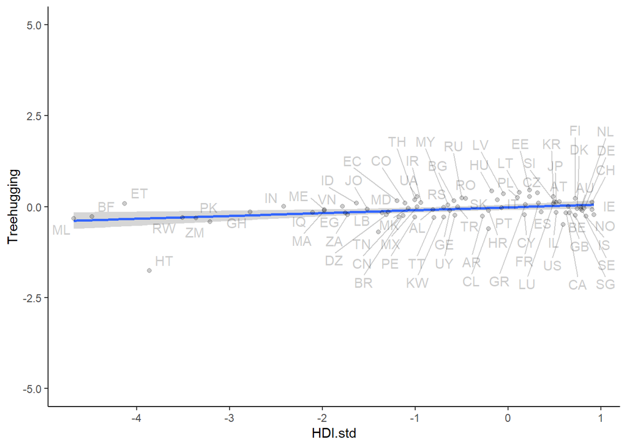

Does this effect hold when controlling for geographic and cultural proximity between countries?

```
##  Family: gaussian
##   Links: mu = identity; sigma = identity
## Formula: Treehugging ~ 1 + HDI.std + Gender + Age.std + RelAttend.std + LeftRight.std + Income.std + (1 + Gender + Age.std + RelAttend.std + LeftRight.std + Income.std | iso) + (1 | gr(isoGeo, cov = geoCov)) + (1 | gr(isoLin, cov = linCov))
##    Data: d (Number of observations: 367928)
##   Draws: 4 chains, each with iter = 4000; warmup = 2000; thin = 1;
##          total post-warmup draws = 8000
##
## Group-Level Effects:
## ~iso (Number of levels: 77)
##                                  Estimate Est.Error l-95% CI u-95% CI Rhat Bulk_ESS Tail_ESS
## sd(Intercept)                        0.07      0.05     0.00     0.21 1.03      126       57
## sd(GenderMale)                       0.09      0.01     0.07     0.11 1.00     4130     5341
## sd(Age.std)                          0.09      0.01     0.07     0.10 1.00     5119     6174
## sd(RelAttend.std)                    0.04      0.01     0.03     0.05 1.00     4286     5693
## sd(LeftRight.std)                    0.06      0.01     0.05     0.08 1.00     4758     6017
## sd(Income.std)                       0.07      0.01     0.06     0.09 1.00     3943     5946
## cor(Intercept,GenderMale)           -0.07      0.36    -0.72     0.65 1.01      265      713
## cor(Intercept,Age.std)              -0.25      0.35    -0.80     0.52 1.02      256      490
## cor(GenderMale,Age.std)              0.54      0.10     0.32     0.72 1.00     4162     5867
## cor(Intercept,RelAttend.std)         0.00      0.35    -0.66     0.69 1.01      400      671
## cor(GenderMale,RelAttend.std)       -0.24      0.15    -0.51     0.06 1.00     5041     6034
## cor(Age.std,RelAttend.std)          -0.22      0.14    -0.48     0.06 1.00     6266     6739
## cor(Intercept,LeftRight.std)         0.16      0.34    -0.58     0.77 1.02      208      397
## cor(GenderMale,LeftRight.std)       -0.46      0.12    -0.67    -0.20 1.00     3515     4612
## cor(Age.std,LeftRight.std)          -0.49      0.10    -0.67    -0.26 1.00     4430     5650
## cor(RelAttend.std,LeftRight.std)     0.33      0.15     0.02     0.59 1.00     3661     5392
## cor(Intercept,Income.std)           -0.14      0.34    -0.73     0.57 1.01      158      451
## cor(GenderMale,Income.std)           0.11      0.15    -0.19     0.39 1.00     3732     5027
## cor(Age.std,Income.std)              0.16      0.13    -0.10     0.41 1.00     4314     5325
## cor(RelAttend.std,Income.std)        0.13      0.16    -0.19     0.44 1.00     4075     5679
## cor(LeftRight.std,Income.std)       -0.29      0.13    -0.54    -0.01 1.00     5147     6534
##
## ~isoGeo (Number of levels: 77)
##               Estimate Est.Error l-95% CI u-95% CI Rhat Bulk_ESS Tail_ESS
## sd(Intercept)     0.23      0.06     0.03     0.31 1.04      124       38
##
## ~isoLin (Number of levels: 77)
##               Estimate Est.Error l-95% CI u-95% CI Rhat Bulk_ESS Tail_ESS
## sd(Intercept)     0.14      0.07     0.01     0.27 1.02      477     1123
##
## Population-Level Effects:
##               Estimate Est.Error l-95% CI u-95% CI Rhat Bulk_ESS Tail_ESS
## Intercept        -0.04      0.09    -0.22     0.15 1.01     1484     3943
## HDI.std           0.07      0.03     0.01     0.13 1.00     1483     4507
## GenderMale        0.07      0.01     0.04     0.09 1.00     4215     5292
## Age.std           0.08      0.01     0.06     0.10 1.00     5054     5430
## RelAttend.std    -0.03      0.01    -0.05    -0.02 1.00     6411     6414
## LeftRight.std    -0.02      0.01    -0.03     0.00 1.00     5337     5525
## Income.std        0.01      0.01    -0.01     0.03 1.00     6847     6096
##
## Family Specific Parameters:
##       Estimate Est.Error l-95% CI u-95% CI Rhat Bulk_ESS Tail_ESS
## sigma     1.16      0.00     1.15     1.16 1.00     7759     4488
##
## Draws were sampled using sampling(NUTS). For each parameter, Bulk_ESS
## and Tail_ESS are effective sample size measures, and Rhat is the potential
## scale reduction factor on split chains (at convergence, Rhat = 1).
```

Yes, it does.

# Environmental Performance Index (EPI)

We also fit a model that includes EPI as a standardised country-level predictor, controlling for individual-level demographics.

```
##  Family: gaussian
##   Links: mu = identity; sigma = identity
## Formula: Treehugging ~ 1 + EPI.std + Gender + Age.std + RelAttend.std + LeftRight.std + Income.std + (1 + Gender + Age.std + RelAttend.std + LeftRight.std + Income.std | iso)
##    Data: d (Number of observations: 365092)
##   Draws: 4 chains, each with iter = 4000; warmup = 2000; thin = 1;
##          total post-warmup draws = 8000
##
## Group-Level Effects:
## ~iso (Number of levels: 73)
##                                  Estimate Est.Error l-95% CI u-95% CI Rhat Bulk_ESS Tail_ESS
## sd(Intercept)                        0.31      0.03     0.26     0.37 1.00     1340     2761
## sd(GenderMale)                       0.09      0.01     0.07     0.10 1.00     2537     4550
## sd(Age.std)                          0.09      0.01     0.07     0.11 1.00     2568     4079
## sd(RelAttend.std)                    0.04      0.01     0.03     0.05 1.00     3467     5099
## sd(LeftRight.std)                    0.06      0.01     0.05     0.08 1.00     3139     4933
## sd(Income.std)                       0.07      0.01     0.05     0.09 1.00     3278     4806
## cor(Intercept,GenderMale)           -0.20      0.14    -0.46     0.09 1.00     1230     2891
## cor(Intercept,Age.std)              -0.30      0.13    -0.54    -0.03 1.00      991     2668
## cor(GenderMale,Age.std)              0.58      0.10     0.37     0.76 1.00     1797     3466
## cor(Intercept,RelAttend.std)        -0.02      0.14    -0.30     0.26 1.00     2100     4038
## cor(GenderMale,RelAttend.std)       -0.23      0.15    -0.51     0.06 1.00     2632     4543
## cor(Age.std,RelAttend.std)          -0.19      0.14    -0.46     0.08 1.00     3049     5028
## cor(Intercept,LeftRight.std)         0.25      0.12     0.00     0.48 1.00     1917     3758
## cor(GenderMale,LeftRight.std)       -0.44      0.12    -0.65    -0.19 1.00     2024     3624
## cor(Age.std,LeftRight.std)          -0.48      0.11    -0.66    -0.25 1.00     2448     4438
## cor(RelAttend.std,LeftRight.std)     0.38      0.14     0.09     0.63 1.00     2186     3741
## cor(Intercept,Income.std)           -0.18      0.13    -0.44     0.08 1.00     3501     4949
## cor(GenderMale,Income.std)           0.12      0.15    -0.18     0.41 1.00     1677     3016
## cor(Age.std,Income.std)              0.14      0.14    -0.12     0.40 1.00     2410     4091
## cor(RelAttend.std,Income.std)        0.16      0.16    -0.16     0.46 1.00     1618     2731
## cor(LeftRight.std,Income.std)       -0.28      0.14    -0.53    -0.00 1.00     2610     4434
##
## Population-Level Effects:
##               Estimate Est.Error l-95% CI u-95% CI Rhat Bulk_ESS Tail_ESS
## Intercept        -0.03      0.04    -0.11     0.06 1.01      372      833
## EPI.std           0.11      0.04     0.03     0.18 1.00      480     1046
## GenderMale        0.07      0.01     0.05     0.09 1.00     2112     3913
## Age.std           0.08      0.01     0.06     0.10 1.00     1676     3304
## RelAttend.std    -0.03      0.01    -0.05    -0.02 1.00     3437     5312
## LeftRight.std    -0.01      0.01    -0.03     0.00 1.00     2282     4144
## Income.std        0.01      0.01    -0.01     0.03 1.00     2876     4476
##
## Family Specific Parameters:
##       Estimate Est.Error l-95% CI u-95% CI Rhat Bulk_ESS Tail_ESS
## sigma     1.16      0.00     1.15     1.16 1.00     7909     4177
##
## Draws were sampled using sampling(NUTS). For each parameter, Bulk_ESS
## and Tail_ESS are effective sample size measures, and Rhat is the potential
## scale reduction factor on split chains (at convergence, Rhat = 1).
```

There is a similar small positive effect of EPI. As EPI increases by one standard deviation, the outcome variable increases by 0.11. We can visualise this effect.

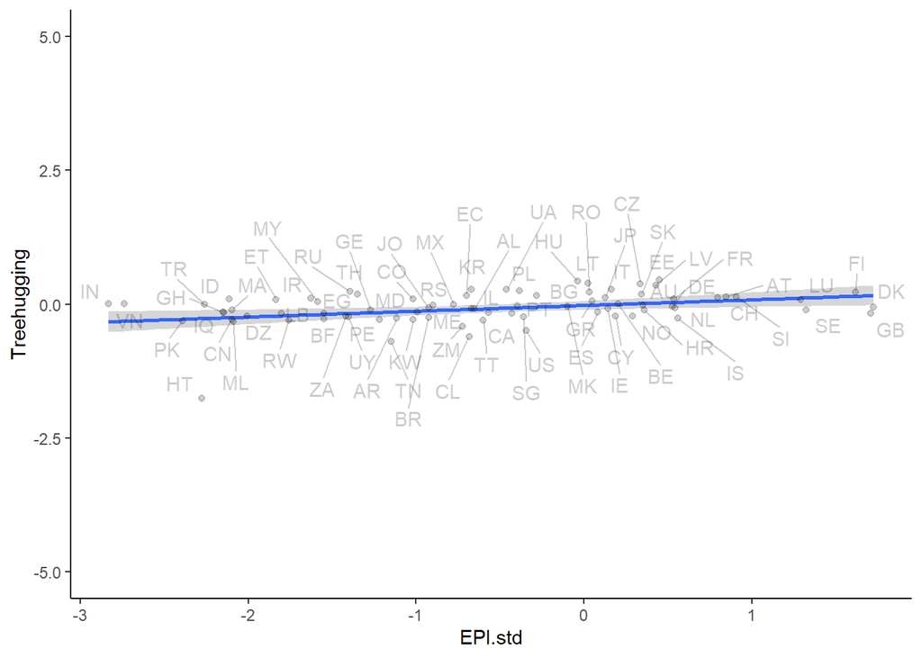

Does this effect hold when controlling for geographic and cultural proximity?

```
##  Family: gaussian
##   Links: mu = identity; sigma = identity
## Formula: Treehugging ~ 1 + EPI.std + Gender + Age.std + RelAttend.std + LeftRight.std + Income.std + (1 + Gender + Age.std + RelAttend.std + LeftRight.std + Income.std | iso) + (1 | gr(isoGeo, cov = geoCov)) + (1 | gr(isoLin, cov = linCov))
##    Data: d (Number of observations: 365092)
##   Draws: 4 chains, each with iter = 4000; warmup = 2000; thin = 1;
##          total post-warmup draws = 8000
##
## Group-Level Effects:
## ~iso (Number of levels: 73)
##                                  Estimate Est.Error l-95% CI u-95% CI Rhat Bulk_ESS Tail_ESS
## sd(Intercept)                        0.09      0.05     0.01     0.20 1.02      342     1219
## sd(GenderMale)                       0.09      0.01     0.07     0.10 1.00     3877     4760
## sd(Age.std)                          0.09      0.01     0.08     0.11 1.00     3902     4993
## sd(RelAttend.std)                    0.04      0.01     0.03     0.05 1.00     3846     5207
## sd(LeftRight.std)                    0.06      0.01     0.05     0.08 1.00     4236     5846
## sd(Income.std)                       0.07      0.01     0.05     0.09 1.00     3515     4766
## cor(Intercept,GenderMale)           -0.11      0.32    -0.69     0.54 1.02      262      579
## cor(Intercept,Age.std)              -0.37      0.32    -0.84     0.38 1.02      290      376
## cor(GenderMale,Age.std)              0.58      0.10     0.36     0.75 1.00     3891     5548
## cor(Intercept,RelAttend.std)        -0.02      0.32    -0.64     0.58 1.01      338      757
## cor(GenderMale,RelAttend.std)       -0.23      0.15    -0.50     0.07 1.00     3776     5130
## cor(Age.std,RelAttend.std)          -0.19      0.14    -0.45     0.09 1.00     4425     5348
## cor(Intercept,LeftRight.std)         0.27      0.31    -0.41     0.78 1.01      257      413
## cor(GenderMale,LeftRight.std)       -0.44      0.12    -0.66    -0.18 1.00     3143     4609
## cor(Age.std,LeftRight.std)          -0.48      0.10    -0.66    -0.26 1.00     4105     5584
## cor(RelAttend.std,LeftRight.std)     0.37      0.14     0.07     0.62 1.00     3237     4631
## cor(Intercept,Income.std)           -0.24      0.32    -0.77     0.49 1.04      132      127
## cor(GenderMale,Income.std)           0.12      0.15    -0.18     0.41 1.00     3142     4619
## cor(Age.std,Income.std)              0.15      0.14    -0.13     0.41 1.00     4355     5778
## cor(RelAttend.std,Income.std)        0.16      0.16    -0.17     0.46 1.00     3204     5514
## cor(LeftRight.std,Income.std)       -0.28      0.14    -0.54    -0.01 1.00     4308     5888
##
## ~isoGeo (Number of levels: 73)
##               Estimate Est.Error l-95% CI u-95% CI Rhat Bulk_ESS Tail_ESS
## sd(Intercept)     0.25      0.04     0.17     0.33 1.01      750     1249
##
## ~isoLin (Number of levels: 73)
##               Estimate Est.Error l-95% CI u-95% CI Rhat Bulk_ESS Tail_ESS
## sd(Intercept)     0.12      0.07     0.01     0.26 1.00      479     1548
##
## Population-Level Effects:
##               Estimate Est.Error l-95% CI u-95% CI Rhat Bulk_ESS Tail_ESS
## Intercept        -0.06      0.10    -0.24     0.13 1.00     2014     3071
## EPI.std           0.07      0.04    -0.01     0.16 1.00     1258     2980
## GenderMale        0.07      0.01     0.05     0.09 1.00     3450     4832
## Age.std           0.08      0.01     0.06     0.10 1.00     3956     4533
## RelAttend.std    -0.03      0.01    -0.05    -0.02 1.00     4098     5196
## LeftRight.std    -0.01      0.01    -0.03     0.00 1.00     3717     3925
## Income.std        0.01      0.01    -0.01     0.03 1.00     4671     4541
##
## Family Specific Parameters:
##       Estimate Est.Error l-95% CI u-95% CI Rhat Bulk_ESS Tail_ESS
## sigma     1.16      0.00     1.15     1.16 1.00     9058     4712
##
## Draws were sampled using sampling(NUTS). For each parameter, Bulk_ESS
## and Tail_ESS are effective sample size measures, and Rhat is the potential
## scale reduction factor on split chains (at convergence, Rhat = 1).
```

The 95% credible interval for the slope now includes zero. But the majority of the posterior remains positive, suggesting that the effect holds.